# Risk Factor Analysis

## Outcome Variable

**Outcome Variable:** ever_stunted

## Predictor Variables

**Intervention Variable:** mwtkg

**Adjustment Set:**

unadjusted

## Stratifying Variables

The analysis was stratified on these variable(s):

- agecat
- studyid
- country

## Data Summary

| agecat | studyid | country | mwtkg | ever_stunted | n_cell | n |
| --- | --- | --- | --- | --- | --- | --- |
| 0-24 months | ki0047075b-MAL-ED | BANGLADESH | >=58 kg | 0 | 29 | 254 |
| 0-24 months | ki0047075b-MAL-ED | BANGLADESH | >=58 kg | 1 | 19 | 254 |
| 0-24 months | ki0047075b-MAL-ED | BANGLADESH | <52 kg | 0 | 49 | 254 |
| 0-24 months | ki0047075b-MAL-ED | BANGLADESH | <52 kg | 1 | 113 | 254 |
| 0-24 months | ki0047075b-MAL-ED | BANGLADESH | [52-58) kg | 0 | 21 | 254 |
| 0-24 months | ki0047075b-MAL-ED | BANGLADESH | [52-58) kg | 1 | 23 | 254 |
| 0-24 months | ki0047075b-MAL-ED | BRAZIL | >=58 kg | 0 | 110 | 221 |
| 0-24 months | ki0047075b-MAL-ED | BRAZIL | >=58 kg | 1 | 33 | 221 |
| 0-24 months | ki0047075b-MAL-ED | BRAZIL | <52 kg | 0 | 31 | 221 |
| 0-24 months | ki0047075b-MAL-ED | BRAZIL | <52 kg | 1 | 11 | 221 |
| 0-24 months | ki0047075b-MAL-ED | BRAZIL | [52-58) kg | 0 | 30 | 221 |
| 0-24 months | ki0047075b-MAL-ED | BRAZIL | [52-58) kg | 1 | 6 | 221 |
| 0-24 months | ki0047075b-MAL-ED | INDIA | >=58 kg | 0 | 23 | 242 |
| 0-24 months | ki0047075b-MAL-ED | INDIA | >=58 kg | 1 | 19 | 242 |
| 0-24 months | ki0047075b-MAL-ED | INDIA | <52 kg | 0 | 51 | 242 |
| 0-24 months | ki0047075b-MAL-ED | INDIA | <52 kg | 1 | 99 | 242 |
| 0-24 months | ki0047075b-MAL-ED | INDIA | [52-58) kg | 0 | 21 | 242 |
| 0-24 months | ki0047075b-MAL-ED | INDIA | [52-58) kg | 1 | 29 | 242 |
| 0-24 months | ki0047075b-MAL-ED | NEPAL | >=58 kg | 0 | 58 | 238 |
| 0-24 months | ki0047075b-MAL-ED | NEPAL | >=58 kg | 1 | 22 | 238 |
| 0-24 months | ki0047075b-MAL-ED | NEPAL | <52 kg | 0 | 37 | 238 |
| 0-24 months | ki0047075b-MAL-ED | NEPAL | <52 kg | 1 | 39 | 238 |
| 0-24 months | ki0047075b-MAL-ED | NEPAL | [52-58) kg | 0 | 61 | 238 |
| 0-24 months | ki0047075b-MAL-ED | NEPAL | [52-58) kg | 1 | 21 | 238 |
| 0-24 months | ki0047075b-MAL-ED | PERU | >=58 kg | 0 | 42 | 290 |
| 0-24 months | ki0047075b-MAL-ED | PERU | >=58 kg | 1 | 62 | 290 |
| 0-24 months | ki0047075b-MAL-ED | PERU | <52 kg | 0 | 42 | 290 |
| 0-24 months | ki0047075b-MAL-ED | PERU | <52 kg | 1 | 73 | 290 |
| 0-24 months | ki0047075b-MAL-ED | PERU | [52-58) kg | 0 | 20 | 290 |
| 0-24 months | ki0047075b-MAL-ED | PERU | [52-58) kg | 1 | 51 | 290 |

[output cut: 252 more lines]

The following strata were considered:

- agecat: 0-24 months, studyid: ki0047075b-MAL-ED, country: BANGLADESH
- agecat: 0-24 months, studyid: ki0047075b-MAL-ED, country: BRAZIL
- agecat: 0-24 months, studyid: ki0047075b-MAL-ED, country: INDIA
- agecat: 0-24 months, studyid: ki0047075b-MAL-ED, country: NEPAL
- agecat: 0-24 months, studyid: ki0047075b-MAL-ED, country: PERU
- agecat: 0-24 months, studyid: ki0047075b-MAL-ED, country: SOUTH AFRICA
- agecat: 0-24 months, studyid: ki0047075b-MAL-ED, country: TANZANIA, UNITED REPUBLIC OF
- agecat: 0-24 months, studyid: ki1000304b-SAS-CompFeed, country: INDIA
- agecat: 0-24 months, studyid: ki1017093-NIH-Birth, country: BANGLADESH
- agecat: 0-24 months, studyid: ki1017093b-PROVIDE, country: BANGLADESH
- agecat: 0-24 months, studyid: ki1017093c-NIH-Crypto, country: BANGLADESH
- agecat: 0-24 months, studyid: ki1066203-TanzaniaChild2, country: TANZANIA, UNITED REPUBLIC OF
- agecat: 0-24 months, studyid: ki1112895-iLiNS-Zinc, country: BURKINA FASO
- agecat: 0-24 months, studyid: ki1119695-PROBIT, country: BELARUS
- agecat: 0-24 months, studyid: ki1126311-ZVITAMBO, country: ZIMBABWE
- agecat: 0-24 months, studyid: ki1148112-LCNI-5, country: MALAWI
- agecat: 0-6 months, studyid: ki0047075b-MAL-ED, country: BANGLADESH
- agecat: 0-6 months, studyid: ki0047075b-MAL-ED, country: BRAZIL
- agecat: 0-6 months, studyid: ki0047075b-MAL-ED, country: INDIA
- agecat: 0-6 months, studyid: ki0047075b-MAL-ED, country: NEPAL
- agecat: 0-6 months, studyid: ki0047075b-MAL-ED, country: PERU
- agecat: 0-6 months, studyid: ki0047075b-MAL-ED, country: SOUTH AFRICA
- agecat: 0-6 months, studyid: ki0047075b-MAL-ED, country: TANZANIA, UNITED REPUBLIC OF
- agecat: 0-6 months, studyid: ki1000304b-SAS-CompFeed, country: INDIA
- agecat: 0-6 months, studyid: ki1017093-NIH-Birth, country: BANGLADESH
- agecat: 0-6 months, studyid: ki1017093b-PROVIDE, country: BANGLADESH
- agecat: 0-6 months, studyid: ki1017093c-NIH-Crypto, country: BANGLADESH
- agecat: 0-6 months, studyid: ki1066203-TanzaniaChild2, country: TANZANIA, UNITED REPUBLIC OF
- agecat: 0-6 months, studyid: ki1119695-PROBIT, country: BELARUS
- agecat: 0-6 months, studyid: ki1126311-ZVITAMBO, country: ZIMBABWE
- agecat: 0-6 months, studyid: ki1148112-LCNI-5, country: MALAWI
- agecat: 6-24 months, studyid: ki0047075b-MAL-ED, country: BANGLADESH
- agecat: 6-24 months, studyid: ki0047075b-MAL-ED, country: BRAZIL
- agecat: 6-24 months, studyid: ki0047075b-MAL-ED, country: INDIA
- agecat: 6-24 months, studyid: ki0047075b-MAL-ED, country: NEPAL
- agecat: 6-24 months, studyid: ki0047075b-MAL-ED, country: PERU
- agecat: 6-24 months, studyid: ki0047075b-MAL-ED, country: SOUTH AFRICA
- agecat: 6-24 months, studyid: ki0047075b-MAL-ED, country: TANZANIA, UNITED REPUBLIC OF
- agecat: 6-24 months, studyid: ki1000304b-SAS-CompFeed, country: INDIA
- agecat: 6-24 months, studyid: ki1017093-NIH-Birth, country: BANGLADESH
- agecat: 6-24 months, studyid: ki1017093b-PROVIDE, country: BANGLADESH
- agecat: 6-24 months, studyid: ki1017093c-NIH-Crypto, country: BANGLADESH
- agecat: 6-24 months, studyid: ki1066203-TanzaniaChild2, country: TANZANIA, UNITED REPUBLIC OF
- agecat: 6-24 months, studyid: ki1112895-iLiNS-Zinc, country: BURKINA FASO
- agecat: 6-24 months, studyid: ki1119695-PROBIT, country: BELARUS
- agecat: 6-24 months, studyid: ki1126311-ZVITAMBO, country: ZIMBABWE
- agecat: 6-24 months, studyid: ki1148112-LCNI-5, country: MALAWI

### Dropped Strata

Some strata were dropped due to rare outcomes:

- agecat: 6-24 months, studyid: ki0047075b-MAL-ED, country: BRAZIL

## Methods Detail

We’re interested in the causal parameters $E[Y_a]$ for all values of $a \in \mathcal{A}$. These parameters represent the mean outcome if, possibly contrary to fact, we intervened to set all units to have $A=a$. Under the randomization and positivity assumptions, these are identified by the statistical parameters $\psi_a=E_W[E_{Y|A,W}(Y|A=a,W)]$. In addition, we’re interested in the mean of $Y$, $E[Y]$ under no intervention (the observed mean). We will estimate these parameters by using SuperLearner to fit the relevant likelihood factors – $E_{Y|A,W}(Y|A=a,W)$ and $p(A=a|W)$, and then updating our likelihood fit using a joint TMLE.

For unadjusted analyses ($W=\{\}$), initial likelihoods were estimated using Lrnr_glm to estimate the simple $E(Y|A)$ and Lrnr_mean to estimate $p(A)$. For adjusted analyses, a small library containing Lrnr_glmnet, Lrnr_xgboost, and Lrnr_mean was used.

Having estimated these parameters, we will then use the delta method to estimate relative risks and attributable risks relative to a prespecified baseline level of $A$.

# Results Detail

## Results Plots

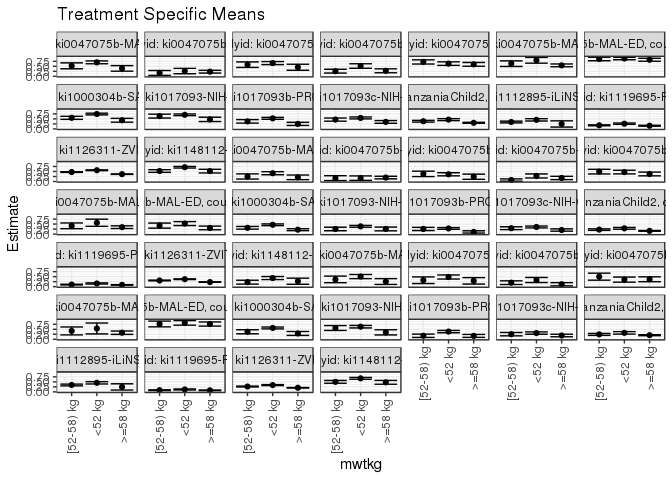

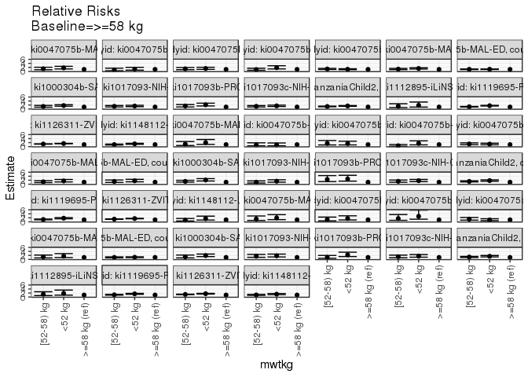

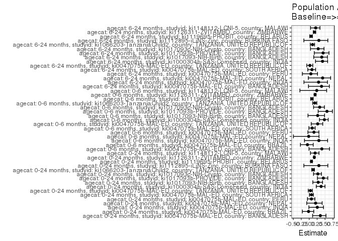

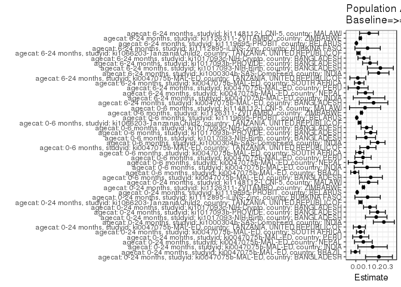

## Results Table

### Parameter: TSM

| agecat | studyid | country | intervention_level | baseline_level | estimate | ci_lower | ci_upper |
| --- | --- | --- | --- | --- | --- | --- | --- |
| 0-24 months | ki0047075b-MAL-ED | BANGLADESH | >=58 kg | NA | 0.3958333 | 0.2572157 | 0.5344510 |
| 0-24 months | ki0047075b-MAL-ED | BANGLADESH | <52 kg | NA | 0.6975309 | 0.6266597 | 0.7684020 |
| 0-24 months | ki0047075b-MAL-ED | BANGLADESH | [52-58) kg | NA | 0.5227273 | 0.3748507 | 0.6706038 |
| 0-24 months | ki0047075b-MAL-ED | BRAZIL | >=58 kg | NA | 0.2307692 | 0.1615571 | 0.2999813 |
| 0-24 months | ki0047075b-MAL-ED | BRAZIL | <52 kg | NA | 0.2619048 | 0.1286336 | 0.3951759 |
| 0-24 months | ki0047075b-MAL-ED | BRAZIL | [52-58) kg | NA | 0.1666667 | 0.0446511 | 0.2886823 |
| 0-24 months | ki0047075b-MAL-ED | INDIA | >=58 kg | NA | 0.4523810 | 0.3015418 | 0.6032201 |
| 0-24 months | ki0047075b-MAL-ED | INDIA | <52 kg | NA | 0.6600000 | 0.5840351 | 0.7359649 |
| 0-24 months | ki0047075b-MAL-ED | INDIA | [52-58) kg | NA | 0.5800000 | 0.4429115 | 0.7170885 |
| 0-24 months | ki0047075b-MAL-ED | NEPAL | >=58 kg | NA | 0.2750000 | 0.1769488 | 0.3730512 |
| 0-24 months | ki0047075b-MAL-ED | NEPAL | <52 kg | NA | 0.5131579 | 0.4005484 | 0.6257674 |
| 0-24 months | ki0047075b-MAL-ED | NEPAL | [52-58) kg | NA | 0.2560976 | 0.1614267 | 0.3507684 |
| 0-24 months | ki0047075b-MAL-ED | PERU | >=58 kg | NA | 0.5961538 | 0.5016893 | 0.6906184 |
| 0-24 months | ki0047075b-MAL-ED | PERU | <52 kg | NA | 0.6347826 | 0.5466295 | 0.7229357 |
| 0-24 months | ki0047075b-MAL-ED | PERU | [52-58) kg | NA | 0.7183099 | 0.6134979 | 0.8231218 |
| 0-24 months | ki0047075b-MAL-ED | SOUTH AFRICA | >=58 kg | NA | 0.5463918 | 0.4762066 | 0.6165769 |
| 0-24 months | ki0047075b-MAL-ED | SOUTH AFRICA | <52 kg | NA | 0.8000000 | 0.6565987 | 0.9434013 |
| 0-24 months | ki0047075b-MAL-ED | SOUTH AFRICA | [52-58) kg | NA | 0.6304348 | 0.4906884 | 0.7701812 |
| 0-24 months | ki0047075b-MAL-ED | TANZANIA, UNITED REPUBLIC OF | >=58 kg | NA | 0.8265306 | 0.7514158 | 0.9016455 |
| 0-24 months | ki0047075b-MAL-ED | TANZANIA, UNITED REPUBLIC OF | <52 kg | NA | 0.8888889 | 0.8268616 | 0.9509162 |
| 0-24 months | ki0047075b-MAL-ED | TANZANIA, UNITED REPUBLIC OF | [52-58) kg | NA | 0.8644068 | 0.7768782 | 0.9519354 |
| 0-24 months | ki1000304b-SAS-CompFeed | INDIA | >=58 kg | NA | 0.4311927 | 0.3357012 | 0.5266841 |
| 0-24 months | ki1000304b-SAS-CompFeed | INDIA | <52 kg | NA | 0.7431507 | 0.7007461 | 0.7855552 |
| 0-24 months | ki1000304b-SAS-CompFeed | INDIA | [52-58) kg | NA | 0.5527426 | 0.4772008 | 0.6282844 |
| 0-24 months | ki1017093-NIH-Birth | BANGLADESH | >=58 kg | NA | 0.4756098 | 0.3674317 | 0.5837879 |
| 0-24 months | ki1017093-NIH-Birth | BANGLADESH | <52 kg | NA | 0.7041943 | 0.6621319 | 0.7462567 |
| 0-24 months | ki1017093-NIH-Birth | BANGLADESH | [52-58) kg | NA | 0.6382979 | 0.5410865 | 0.7355092 |
| 0-24 months | ki1017093b-PROVIDE | BANGLADESH | >=58 kg | NA | 0.2500000 | 0.1724677 | 0.3275323 |
| 0-24 months | ki1017093b-PROVIDE | BANGLADESH | <52 kg | NA | 0.5277778 | 0.4806660 | 0.5748896 |
| 0-24 months | ki1017093b-PROVIDE | BANGLADESH | [52-58) kg | NA | 0.3760684 | 0.2882305 | 0.4639063 |

[output cut: 108 more lines]

### Parameter: E(Y)

| agecat | studyid | country | intervention_level | baseline_level | estimate | ci_lower | ci_upper |
| --- | --- | --- | --- | --- | --- | --- | --- |
| 0-24 months | ki0047075b-MAL-ED | BANGLADESH | NA | NA | 0.6102362 | 0.5501413 | 0.6703311 |
| 0-24 months | ki0047075b-MAL-ED | BRAZIL | NA | NA | 0.2262443 | 0.1709568 | 0.2815319 |
| 0-24 months | ki0047075b-MAL-ED | INDIA | NA | NA | 0.6074380 | 0.5457864 | 0.6690897 |
| 0-24 months | ki0047075b-MAL-ED | NEPAL | NA | NA | 0.3445378 | 0.2840363 | 0.4050393 |
| 0-24 months | ki0047075b-MAL-ED | PERU | NA | NA | 0.6413793 | 0.5860858 | 0.6966728 |
| 0-24 months | ki0047075b-MAL-ED | SOUTH AFRICA | NA | NA | 0.5888889 | 0.5300901 | 0.6476877 |
| 0-24 months | ki0047075b-MAL-ED | TANZANIA, UNITED REPUBLIC OF | NA | NA | 0.8593750 | 0.8167072 | 0.9020428 |
| 0-24 months | ki1000304b-SAS-CompFeed | INDIA | NA | NA | 0.6908851 | 0.6500577 | 0.7317124 |
| 0-24 months | ki1017093-NIH-Birth | BANGLADESH | NA | NA | 0.6645469 | 0.6276196 | 0.7014742 |
| 0-24 months | ki1017093b-PROVIDE | BANGLADESH | NA | NA | 0.4514200 | 0.4136828 | 0.4891573 |
| 0-24 months | ki1017093c-NIH-Crypto | BANGLADESH | NA | NA | 0.4794702 | 0.4438115 | 0.5151289 |
| 0-24 months | ki1066203-TanzaniaChild2 | TANZANIA, UNITED REPUBLIC OF | NA | NA | 0.3465136 | 0.3272783 | 0.3657490 |
| 0-24 months | ki1112895-iLiNS-Zinc | BURKINA FASO | NA | NA | 0.3559962 | 0.3060347 | 0.4059578 |
| 0-24 months | ki1119695-PROBIT | BELARUS | NA | NA | 0.1694743 | 0.1504830 | 0.1884655 |
| 0-24 months | ki1126311-ZVITAMBO | ZIMBABWE | NA | NA | 0.4356480 | 0.4264663 | 0.4448297 |
| 0-24 months | ki1148112-LCNI-5 | MALAWI | NA | NA | 0.6360382 | 0.6034429 | 0.6686335 |
| 0-6 months | ki0047075b-MAL-ED | BANGLADESH | NA | NA | 0.3464567 | 0.2878227 | 0.4050907 |
| 0-6 months | ki0047075b-MAL-ED | BRAZIL | NA | NA | 0.1855204 | 0.1341547 | 0.2368860 |
| 0-6 months | ki0047075b-MAL-ED | INDIA | NA | NA | 0.3429752 | 0.2830428 | 0.4029076 |
| 0-6 months | ki0047075b-MAL-ED | NEPAL | NA | NA | 0.1722689 | 0.1241936 | 0.2203442 |
| 0-6 months | ki0047075b-MAL-ED | PERU | NA | NA | 0.4413793 | 0.3841309 | 0.4986278 |
| 0-6 months | ki0047075b-MAL-ED | SOUTH AFRICA | NA | NA | 0.3814815 | 0.3234338 | 0.4395292 |
| 0-6 months | ki0047075b-MAL-ED | TANZANIA, UNITED REPUBLIC OF | NA | NA | 0.4179688 | 0.3574314 | 0.4785061 |
| 0-6 months | ki1000304b-SAS-CompFeed | INDIA | NA | NA | 0.4228987 | 0.3938571 | 0.4519404 |
| 0-6 months | ki1017093-NIH-Birth | BANGLADESH | NA | NA | 0.3497615 | 0.3124631 | 0.3870600 |
| 0-6 months | ki1017093b-PROVIDE | BANGLADESH | NA | NA | 0.2466368 | 0.2139486 | 0.2793250 |
| 0-6 months | ki1017093c-NIH-Crypto | BANGLADESH | NA | NA | 0.3033113 | 0.2704998 | 0.3361228 |
| 0-6 months | ki1066203-TanzaniaChild2 | TANZANIA, UNITED REPUBLIC OF | NA | NA | 0.1943027 | 0.1783091 | 0.2102964 |
| 0-6 months | ki1119695-PROBIT | BELARUS | NA | NA | 0.0970084 | 0.0840167 | 0.1100001 |
| 0-6 months | ki1126311-ZVITAMBO | ZIMBABWE | NA | NA | 0.2815517 | 0.2732174 | 0.2898859 |
| 0-6 months | ki1148112-LCNI-5 | MALAWI | NA | NA | 0.3579336 | 0.3007518 | 0.4151153 |
| 6-24 months | ki0047075b-MAL-ED | BANGLADESH | NA | NA | 0.4213836 | 0.3443902 | 0.4983771 |
| 6-24 months | ki0047075b-MAL-ED | INDIA | NA | NA | 0.4129032 | 0.3351414 | 0.4906651 |
| 6-24 months | ki0047075b-MAL-ED | NEPAL | NA | NA | 0.2102564 | 0.1529155 | 0.2675974 |
| 6-24 months | ki0047075b-MAL-ED | PERU | NA | NA | 0.3918919 | 0.3129763 | 0.4708075 |
| 6-24 months | ki0047075b-MAL-ED | SOUTH AFRICA | NA | NA | 0.3589744 | 0.2834562 | 0.4344926 |
| 6-24 months | ki0047075b-MAL-ED | TANZANIA, UNITED REPUBLIC OF | NA | NA | 0.7793103 | 0.7115754 | 0.8470453 |
| 6-24 months | ki1000304b-SAS-CompFeed | INDIA | NA | NA | 0.5024691 | 0.4579693 | 0.5469690 |
| 6-24 months | ki1017093-NIH-Birth | BANGLADESH | NA | NA | 0.5739130 | 0.5216565 | 0.6261696 |
| 6-24 months | ki1017093b-PROVIDE | BANGLADESH | NA | NA | 0.2997812 | 0.2577294 | 0.3418330 |
| 6-24 months | ki1017093c-NIH-Crypto | BANGLADESH | NA | NA | 0.2628458 | 0.2244546 | 0.3012371 |
| 6-24 months | ki1066203-TanzaniaChild2 | TANZANIA, UNITED REPUBLIC OF | NA | NA | 0.2277354 | 0.2069978 | 0.2484730 |
| 6-24 months | ki1112895-iLiNS-Zinc | BURKINA FASO | NA | NA | 0.3559962 | 0.3060347 | 0.4059578 |
| 6-24 months | ki1119695-PROBIT | BELARUS | NA | NA | 0.0803025 | 0.0658938 | 0.0947113 |
| 6-24 months | ki1126311-ZVITAMBO | ZIMBABWE | NA | NA | 0.2460554 | 0.2359900 | 0.2561209 |
| 6-24 months | ki1148112-LCNI-5 | MALAWI | NA | NA | 0.5989011 | 0.5632737 | 0.6345285 |

### Parameter: RR

| agecat | studyid | country | intervention_level | baseline_level | estimate | ci_lower | ci_upper |
| --- | --- | --- | --- | --- | --- | --- | --- |
| 0-24 months | ki0047075b-MAL-ED | BANGLADESH | >=58 kg | >=58 kg | 1.0000000 | 1.0000000 | 1.000000 |
| 0-24 months | ki0047075b-MAL-ED | BANGLADESH | <52 kg | >=58 kg | 1.7621832 | 1.2237501 | 2.537520 |
| 0-24 months | ki0047075b-MAL-ED | BANGLADESH | [52-58) kg | >=58 kg | 1.3205742 | 0.8418822 | 2.071449 |
| 0-24 months | ki0047075b-MAL-ED | BRAZIL | >=58 kg | >=58 kg | 1.0000000 | 1.0000000 | 1.000000 |
| 0-24 months | ki0047075b-MAL-ED | BRAZIL | <52 kg | >=58 kg | 1.1349206 | 0.6287002 | 2.048743 |
| 0-24 months | ki0047075b-MAL-ED | BRAZIL | [52-58) kg | >=58 kg | 0.7222222 | 0.3274012 | 1.593167 |
| 0-24 months | ki0047075b-MAL-ED | INDIA | >=58 kg | >=58 kg | 1.0000000 | 1.0000000 | 1.000000 |
| 0-24 months | ki0047075b-MAL-ED | INDIA | <52 kg | >=58 kg | 1.4589474 | 1.0252893 | 2.076026 |
| 0-24 months | ki0047075b-MAL-ED | INDIA | [52-58) kg | >=58 kg | 1.2821053 | 0.8519677 | 1.929409 |
| 0-24 months | ki0047075b-MAL-ED | NEPAL | >=58 kg | >=58 kg | 1.0000000 | 1.0000000 | 1.000000 |
| 0-24 months | ki0047075b-MAL-ED | NEPAL | <52 kg | >=58 kg | 1.8660287 | 1.2277016 | 2.836245 |
| 0-24 months | ki0047075b-MAL-ED | NEPAL | [52-58) kg | >=58 kg | 0.9312639 | 0.5572122 | 1.556413 |
| 0-24 months | ki0047075b-MAL-ED | PERU | >=58 kg | >=58 kg | 1.0000000 | 1.0000000 | 1.000000 |
| 0-24 months | ki0047075b-MAL-ED | PERU | <52 kg | >=58 kg | 1.0647966 | 0.8625050 | 1.314534 |
| 0-24 months | ki0047075b-MAL-ED | PERU | [52-58) kg | >=58 kg | 1.2049069 | 0.9714132 | 1.494524 |
| 0-24 months | ki0047075b-MAL-ED | SOUTH AFRICA | >=58 kg | >=58 kg | 1.0000000 | 1.0000000 | 1.000000 |
| 0-24 months | ki0047075b-MAL-ED | SOUTH AFRICA | <52 kg | >=58 kg | 1.4641509 | 1.1743924 | 1.825402 |
| 0-24 months | ki0047075b-MAL-ED | SOUTH AFRICA | [52-58) kg | >=58 kg | 1.1538146 | 0.8930418 | 1.490734 |
| 0-24 months | ki0047075b-MAL-ED | TANZANIA, UNITED REPUBLIC OF | >=58 kg | >=58 kg | 1.0000000 | 1.0000000 | 1.000000 |
| 0-24 months | ki0047075b-MAL-ED | TANZANIA, UNITED REPUBLIC OF | <52 kg | >=58 kg | 1.0754458 | 0.9590191 | 1.206007 |
| 0-24 months | ki0047075b-MAL-ED | TANZANIA, UNITED REPUBLIC OF | [52-58) kg | >=58 kg | 1.0458255 | 0.9127860 | 1.198256 |
| 0-24 months | ki1000304b-SAS-CompFeed | INDIA | >=58 kg | >=58 kg | 1.0000000 | 1.0000000 | 1.000000 |
| 0-24 months | ki1000304b-SAS-CompFeed | INDIA | <52 kg | >=58 kg | 1.7234771 | 1.3876003 | 2.140655 |
| 0-24 months | ki1000304b-SAS-CompFeed | INDIA | [52-58) kg | >=58 kg | 1.2818924 | 0.9109777 | 1.803829 |
| 0-24 months | ki1017093-NIH-Birth | BANGLADESH | >=58 kg | >=58 kg | 1.0000000 | 1.0000000 | 1.000000 |
| 0-24 months | ki1017093-NIH-Birth | BANGLADESH | <52 kg | >=58 kg | 1.4806136 | 1.1703384 | 1.873148 |
| 0-24 months | ki1017093-NIH-Birth | BANGLADESH | [52-58) kg | >=58 kg | 1.3420622 | 1.0206873 | 1.764626 |
| 0-24 months | ki1017093b-PROVIDE | BANGLADESH | >=58 kg | >=58 kg | 1.0000000 | 1.0000000 | 1.000000 |
| 0-24 months | ki1017093b-PROVIDE | BANGLADESH | <52 kg | >=58 kg | 2.1111111 | 1.5288168 | 2.915189 |
| 0-24 months | ki1017093b-PROVIDE | BANGLADESH | [52-58) kg | >=58 kg | 1.5042735 | 1.0202671 | 2.217889 |

[output cut: 108 more lines]

### Parameter: PAR

| agecat | studyid | country | intervention_level | baseline_level | estimate | ci_lower | ci_upper |
| --- | --- | --- | --- | --- | --- | --- | --- |
| 0-24 months | ki0047075b-MAL-ED | BANGLADESH | >=58 kg | NA | 0.2144029 | 0.0896473 | 0.3391584 |
| 0-24 months | ki0047075b-MAL-ED | BRAZIL | >=58 kg | NA | -0.0045249 | -0.0451180 | 0.0360682 |
| 0-24 months | ki0047075b-MAL-ED | INDIA | >=58 kg | NA | 0.1550571 | 0.0184707 | 0.2916434 |
| 0-24 months | ki0047075b-MAL-ED | NEPAL | >=58 kg | NA | 0.0695378 | -0.0129925 | 0.1520681 |
| 0-24 months | ki0047075b-MAL-ED | PERU | >=58 kg | NA | 0.0452255 | -0.0294778 | 0.1199288 |
| 0-24 months | ki0047075b-MAL-ED | SOUTH AFRICA | >=58 kg | NA | 0.0424971 | 0.0063797 | 0.0786146 |
| 0-24 months | ki0047075b-MAL-ED | TANZANIA, UNITED REPUBLIC OF | >=58 kg | NA | 0.0328444 | -0.0232176 | 0.0889064 |
| 0-24 months | ki1000304b-SAS-CompFeed | INDIA | >=58 kg | NA | 0.2596924 | 0.1621951 | 0.3571897 |
| 0-24 months | ki1017093-NIH-Birth | BANGLADESH | >=58 kg | NA | 0.1889371 | 0.0888626 | 0.2890117 |
| 0-24 months | ki1017093b-PROVIDE | BANGLADESH | >=58 kg | NA | 0.2014200 | 0.1287643 | 0.2740758 |
| 0-24 months | ki1017093c-NIH-Crypto | BANGLADESH | >=58 kg | NA | 0.1305119 | 0.0712826 | 0.1897411 |
| 0-24 months | ki1066203-TanzaniaChild2 | TANZANIA, UNITED REPUBLIC OF | >=58 kg | NA | 0.0429906 | 0.0278385 | 0.0581427 |
| 0-24 months | ki1112895-iLiNS-Zinc | BURKINA FASO | >=58 kg | NA | 0.1089500 | -0.0088494 | 0.2267495 |
| 0-24 months | ki1119695-PROBIT | BELARUS | >=58 kg | NA | 0.0121633 | 0.0078132 | 0.0165134 |
| 0-24 months | ki1126311-ZVITAMBO | ZIMBABWE | >=58 kg | NA | 0.0704246 | 0.0616073 | 0.0792420 |
| 0-24 months | ki1148112-LCNI-5 | MALAWI | >=58 kg | NA | 0.1184943 | 0.0336743 | 0.2033143 |
| 0-6 months | ki0047075b-MAL-ED | BANGLADESH | >=58 kg | NA | 0.1381234 | 0.0300443 | 0.2462024 |
| 0-6 months | ki0047075b-MAL-ED | BRAZIL | >=58 kg | NA | -0.0102838 | -0.0475484 | 0.0269807 |
| 0-6 months | ki0047075b-MAL-ED | INDIA | >=58 kg | NA | 0.1048800 | -0.0154098 | 0.2251697 |
| 0-6 months | ki0047075b-MAL-ED | NEPAL | >=58 kg | NA | -0.0027311 | -0.0705017 | 0.0650396 |
| 0-6 months | ki0047075b-MAL-ED | PERU | >=58 kg | NA | 0.0663793 | -0.0093421 | 0.1421007 |
| 0-6 months | ki0047075b-MAL-ED | SOUTH AFRICA | >=58 kg | NA | 0.0361207 | -0.0013724 | 0.0736137 |
| 0-6 months | ki0047075b-MAL-ED | TANZANIA, UNITED REPUBLIC OF | >=58 kg | NA | 0.1118463 | 0.0368538 | 0.1868388 |
| 0-6 months | ki1000304b-SAS-CompFeed | INDIA | >=58 kg | NA | 0.2027153 | 0.1343047 | 0.2711258 |
| 0-6 months | ki1017093-NIH-Birth | BANGLADESH | >=58 kg | NA | 0.0936640 | 0.0042236 | 0.1831044 |
| 0-6 months | ki1017093b-PROVIDE | BANGLADESH | >=58 kg | NA | 0.1383034 | 0.0830365 | 0.1935704 |
| 0-6 months | ki1017093c-NIH-Crypto | BANGLADESH | >=58 kg | NA | 0.1001863 | 0.0485133 | 0.1518592 |
| 0-6 months | ki1066203-TanzaniaChild2 | TANZANIA, UNITED REPUBLIC OF | >=58 kg | NA | 0.0344111 | 0.0215047 | 0.0473175 |
| 0-6 months | ki1119695-PROBIT | BELARUS | >=58 kg | NA | 0.0083811 | 0.0045535 | 0.0122088 |
| 0-6 months | ki1126311-ZVITAMBO | ZIMBABWE | >=58 kg | NA | 0.0524171 | 0.0443891 | 0.0604452 |
| 0-6 months | ki1148112-LCNI-5 | MALAWI | >=58 kg | NA | 0.0852063 | -0.0590172 | 0.2294298 |
| 6-24 months | ki0047075b-MAL-ED | BANGLADESH | >=58 kg | NA | 0.1642408 | 0.0310577 | 0.2974239 |
| 6-24 months | ki0047075b-MAL-ED | INDIA | >=58 kg | NA | 0.1225806 | -0.0239297 | 0.2690910 |
| 6-24 months | ki0047075b-MAL-ED | NEPAL | >=58 kg | NA | 0.0890443 | 0.0162340 | 0.1618546 |
| 6-24 months | ki0047075b-MAL-ED | PERU | >=58 kg | NA | 0.0209241 | -0.0717484 | 0.1135967 |
| 6-24 months | ki0047075b-MAL-ED | SOUTH AFRICA | >=58 kg | NA | 0.0312433 | -0.0128063 | 0.0752928 |
| 6-24 months | ki0047075b-MAL-ED | TANZANIA, UNITED REPUBLIC OF | >=58 kg | NA | 0.0181163 | -0.0552606 | 0.0914932 |
| 6-24 months | ki1000304b-SAS-CompFeed | INDIA | >=58 kg | NA | 0.2113299 | 0.1149281 | 0.3077317 |
| 6-24 months | ki1017093-NIH-Birth | BANGLADESH | >=58 kg | NA | 0.2277592 | 0.1075739 | 0.3479445 |
| 6-24 months | ki1017093b-PROVIDE | BANGLADESH | >=58 kg | NA | 0.1314643 | 0.0625750 | 0.2003537 |
| 6-24 months | ki1017093c-NIH-Crypto | BANGLADESH | >=58 kg | NA | 0.0749264 | 0.0192990 | 0.1305537 |
| 6-24 months | ki1066203-TanzaniaChild2 | TANZANIA, UNITED REPUBLIC OF | >=58 kg | NA | 0.0240850 | 0.0087303 | 0.0394398 |
| 6-24 months | ki1112895-iLiNS-Zinc | BURKINA FASO | >=58 kg | NA | 0.1089500 | -0.0088494 | 0.2267495 |
| 6-24 months | ki1119695-PROBIT | BELARUS | >=58 kg | NA | 0.0048832 | 0.0016642 | 0.0081023 |
| 6-24 months | ki1126311-ZVITAMBO | ZIMBABWE | >=58 kg | NA | 0.0414341 | 0.0322644 | 0.0506039 |
| 6-24 months | ki1148112-LCNI-5 | MALAWI | >=58 kg | NA | 0.1227106 | 0.0345548 | 0.2108665 |

### Parameter: PAF

| agecat | studyid | country | intervention_level | baseline_level | estimate | ci_lower | ci_upper |
| --- | --- | --- | --- | --- | --- | --- | --- |
| 0-24 months | ki0047075b-MAL-ED | BANGLADESH | >=58 kg | NA | 0.3513441 | 0.1069034 | 0.5288813 |
| 0-24 months | ki0047075b-MAL-ED | BRAZIL | >=58 kg | NA | -0.0200000 | -0.2161373 | 0.1445045 |
| 0-24 months | ki0047075b-MAL-ED | INDIA | >=58 kg | NA | 0.2552640 | -0.0098541 | 0.4507804 |
| 0-24 months | ki0047075b-MAL-ED | NEPAL | >=58 kg | NA | 0.2018293 | -0.0769666 | 0.4084529 |
| 0-24 months | ki0047075b-MAL-ED | PERU | >=58 kg | NA | 0.0705128 | -0.0539896 | 0.1803084 |
| 0-24 months | ki0047075b-MAL-ED | SOUTH AFRICA | >=58 kg | NA | 0.0721649 | 0.0080152 | 0.1321663 |
| 0-24 months | ki0047075b-MAL-ED | TANZANIA, UNITED REPUBLIC OF | >=58 kg | NA | 0.0382189 | -0.0295971 | 0.1015681 |
| 0-24 months | ki1000304b-SAS-CompFeed | INDIA | >=58 kg | NA | 0.3758837 | 0.2225857 | 0.4989529 |
| 0-24 months | ki1017093-NIH-Birth | BANGLADESH | >=58 kg | NA | 0.2843097 | 0.1148337 | 0.4213374 |
| 0-24 months | ki1017093b-PROVIDE | BANGLADESH | >=58 kg | NA | 0.4461921 | 0.2599269 | 0.5855771 |
| 0-24 months | ki1017093c-NIH-Crypto | BANGLADESH | >=58 kg | NA | 0.2722002 | 0.1368983 | 0.3862918 |
| 0-24 months | ki1066203-TanzaniaChild2 | TANZANIA, UNITED REPUBLIC OF | >=58 kg | NA | 0.1240660 | 0.0792695 | 0.1666831 |
| 0-24 months | ki1112895-iLiNS-Zinc | BURKINA FASO | >=58 kg | NA | 0.3060427 | -0.1679589 | 0.5876766 |
| 0-24 months | ki1119695-PROBIT | BELARUS | >=58 kg | NA | 0.0717706 | 0.0435491 | 0.0991594 |
| 0-24 months | ki1126311-ZVITAMBO | ZIMBABWE | >=58 kg | NA | 0.1616549 | 0.1410826 | 0.1817345 |
| 0-24 months | ki1148112-LCNI-5 | MALAWI | >=58 kg | NA | 0.1863006 | 0.0406527 | 0.3098363 |
| 0-6 months | ki0047075b-MAL-ED | BANGLADESH | >=58 kg | NA | 0.3986742 | -0.0057608 | 0.6404785 |
| 0-6 months | ki0047075b-MAL-ED | BRAZIL | >=58 kg | NA | -0.0554324 | -0.2763152 | 0.1272238 |
| 0-6 months | ki0047075b-MAL-ED | INDIA | >=58 kg | NA | 0.3057946 | -0.1486796 | 0.5804564 |
| 0-6 months | ki0047075b-MAL-ED | NEPAL | >=58 kg | NA | -0.0158537 | -0.4962710 | 0.3103130 |
| 0-6 months | ki0047075b-MAL-ED | PERU | >=58 kg | NA | 0.1503906 | -0.0401780 | 0.3060456 |
| 0-6 months | ki0047075b-MAL-ED | SOUTH AFRICA | >=58 kg | NA | 0.0946852 | -0.0092681 | 0.1879315 |
| 0-6 months | ki0047075b-MAL-ED | TANZANIA, UNITED REPUBLIC OF | >=58 kg | NA | 0.2675949 | 0.0640090 | 0.4268991 |
| 0-6 months | ki1000304b-SAS-CompFeed | INDIA | >=58 kg | NA | 0.4793470 | 0.3234321 | 0.5993314 |
| 0-6 months | ki1017093-NIH-Birth | BANGLADESH | >=58 kg | NA | 0.2677938 | -0.0377840 | 0.4833936 |
| 0-6 months | ki1017093b-PROVIDE | BANGLADESH | >=58 kg | NA | 0.5607576 | 0.2831902 | 0.7308436 |
| 0-6 months | ki1017093c-NIH-Crypto | BANGLADESH | >=58 kg | NA | 0.3303084 | 0.1383375 | 0.4795098 |
| 0-6 months | ki1066203-TanzaniaChild2 | TANZANIA, UNITED REPUBLIC OF | >=58 kg | NA | 0.1771006 | 0.1089749 | 0.2400175 |
| 0-6 months | ki1119695-PROBIT | BELARUS | >=58 kg | NA | 0.0863958 | 0.0451083 | 0.1258982 |
| 0-6 months | ki1126311-ZVITAMBO | ZIMBABWE | >=58 kg | NA | 0.1861723 | 0.1573536 | 0.2140054 |
| 0-6 months | ki1148112-LCNI-5 | MALAWI | >=58 kg | NA | 0.2380506 | -0.2925147 | 0.5508238 |
| 6-24 months | ki0047075b-MAL-ED | BANGLADESH | >=58 kg | NA | 0.3897655 | -0.0228150 | 0.6359203 |
| 6-24 months | ki0047075b-MAL-ED | INDIA | >=58 kg | NA | 0.2968750 | -0.1645763 | 0.5754810 |
| 6-24 months | ki0047075b-MAL-ED | NEPAL | >=58 kg | NA | 0.4235033 | -0.0266294 | 0.6762723 |
| 6-24 months | ki0047075b-MAL-ED | PERU | >=58 kg | NA | 0.0533927 | -0.2153095 | 0.2626854 |
| 6-24 months | ki0047075b-MAL-ED | SOUTH AFRICA | >=58 kg | NA | 0.0870348 | -0.0443387 | 0.2018821 |
| 6-24 months | ki0047075b-MAL-ED | TANZANIA, UNITED REPUBLIC OF | >=58 kg | NA | 0.0232466 | -0.0757380 | 0.1131230 |
| 6-24 months | ki1000304b-SAS-CompFeed | INDIA | >=58 kg | NA | 0.4205828 | 0.1988350 | 0.5809549 |
| 6-24 months | ki1017093-NIH-Birth | BANGLADESH | >=58 kg | NA | 0.3968531 | 0.1437372 | 0.5751466 |
| 6-24 months | ki1017093b-PROVIDE | BANGLADESH | >=58 kg | NA | 0.4385344 | 0.1610528 | 0.6242390 |
| 6-24 months | ki1017093c-NIH-Crypto | BANGLADESH | >=58 kg | NA | 0.2850583 | 0.0414740 | 0.4667420 |
| 6-24 months | ki1066203-TanzaniaChild2 | TANZANIA, UNITED REPUBLIC OF | >=58 kg | NA | 0.1057589 | 0.0360797 | 0.1704011 |
| 6-24 months | ki1112895-iLiNS-Zinc | BURKINA FASO | >=58 kg | NA | 0.3060427 | -0.1679589 | 0.5876766 |
| 6-24 months | ki1119695-PROBIT | BELARUS | >=58 kg | NA | 0.0608107 | 0.0184189 | 0.1013716 |
| 6-24 months | ki1126311-ZVITAMBO | ZIMBABWE | >=58 kg | NA | 0.1683935 | 0.1305844 | 0.2045583 |
| 6-24 months | ki1148112-LCNI-5 | MALAWI | >=58 kg | NA | 0.2048930 | 0.0423577 | 0.3398420 |